# 04 Evaluating Regression Supervised Learning Model Quality

When training supervised learning models, such as linear regression, it’s crucial to have ways to evaluate the quality and performance of the model. This assessment helps in determining how well our model generalizes to new, unseen data. Metrics give a quantitative measure of the model’s performance, while visualizations offer a more qualitative or visual understanding. By using both metrics and visualizations, we can get a comprehensive view of the model’s strengths and weaknesses.

The metrics and visualizations discussed in this lecture are not just indicators of model fit. They provide insights into potential problems in the model, the nature of errors it might make, and can suggest directions for model improvement. This lecture will walk through some common metrics and visualizations for regression models and demonstrate their application using R.

Data source: https://www.kaggle.com/competitions/house-prices-advanced-regression-techniques

# Prepare the workspace

```r
options(
  digits = 2,
  scipen = 999,
  warn = -1
)
rm(
  list = ls()
)
library(magrittr)
```

# 1. Load our data, fit a linear regression model

Here we only have the train and test dataset. Remember train and validate are the most important parts so we will split up the train dataset for the purpose of validation because we need it.

```r
M <- readr::read_csv(
  file = "/Users/thienpham/Data Mining/data/prepared_house_prices.csv",
  col_types = "cnnnnnnnnnnnnnnnnnnnnnnnnnnnnnnnnnnnnnnnnnnnnnnnnnnnnnnnnnnnnnnnnnnnnnnnnnnnnnnnccn",
  name_repair = janitor::make_clean_names
) %>%
  dplyr::filter(train_test == "Train") %>%
  dplyr::mutate(
    train_test = ifelse(runif(dplyr::n()) > 0.5,"Validation",train_test) # using a rng if > .5 make it validate
  )


# This is the model after running forward/backward/step wise selection with least variables.
lm_house <- lm(
  formula = box_cox_sale_price ~ lot_area + street + neighborhood +
    condition1 + overall_qual + year_remod_add + exter_qual +
    bsmt_exposure + bsmt_unf_sf + total_bsmt_sf + heating_qc +
    central_air + gr_liv_area + kitchen_abv_gr + functional +
    fireplaces + garage_cars + garage_area + paved_drive + screen_porch +
    sale_type + sale_condition,
  data = M %>%
    dplyr::filter(
      train_test == "Train"
    )
)
lm_house
```

```
##
## Call:
## lm(formula = box_cox_sale_price ~ lot_area + street + neighborhood +
##     condition1 + overall_qual + year_remod_add + exter_qual +
##     bsmt_exposure + bsmt_unf_sf + total_bsmt_sf + heating_qc +
##     central_air + gr_liv_area + kitchen_abv_gr + functional +
##     fireplaces + garage_cars + garage_area + paved_drive + screen_porch +
##     sale_type + sale_condition, data = M %>% dplyr::filter(train_test ==
##     "Train"))
##
## Coefficients:
##    (Intercept)        lot_area          street    neighborhood      condition1
##     4.94814864      0.00223562      0.23005903      0.06721055      0.04161228
##   overall_qual  year_remod_add      exter_qual   bsmt_exposure     bsmt_unf_sf
##     0.03102029      0.00000135      0.04648364     -0.03679611     -0.00189524
##  total_bsmt_sf      heating_qc     central_air     gr_liv_area  kitchen_abv_gr
##     0.00064497      0.03778903      0.09172345      0.45979445     -0.11774702
##     functional      fireplaces     garage_cars     garage_area     paved_drive
##     0.16357580      0.03465564      0.04385625      0.00014620      0.08034846
##   screen_porch       sale_type  sale_condition
##     0.00031409     -0.05799903      0.04559617
```

Now that we have a linear built for evaluation, we can start running predictions for every row of data and then get the residual.

```r
M <- M %>%
  dplyr::mutate(
    predict = predict(
      object = lm_house,
      newdata = M
    ),
    residual = predict - box_cox_sale_price
  )
```

Normally its real - predict but we reverse here so when residual is positive we know its big, if its negative then its small.

## 2. Metrics for Regression Models

### A. Mean Squared Error (MSE)

MSE is the average squared difference between the observed actual outcomes and the outcomes predicted by the model.

$$\text{MSE} =
\frac{1}{n}\sum_{i=1}^{n}(y_i - \hat{y_i})^2$$

### A. Root Mean Squared Error (RMSE)

RMSE is the square root of the mean squared error. It measures the average magnitude of the errors between observed and predicted values.

$$\text{RMSE} = \sqrt{\text{MSE}}$$

### A. Mean Absolute Error (MAE)

MAE measures the average of the absolute differences between the predicted and actual values.

$$\text{MAE} =
\frac{1}{n}\sum_{i=1}^{n}|y_i - \hat{y_i}|$$

```r
M %>%
  dplyr::group_by(train_test) %>%
  dplyr::summarise(
    mean_squared_error = mean((residual)^2),
    root_mean_squared_error = sqrt(mean_squared_error),
    mean_absolute_error = mean(abs(residual))
  )
```

| train_test | mean_squared_error | root_mean_squared_error | mean_absolute_error |
| --- | --- | --- | --- |
| Train | 0.018 | 0.13 | 0.095 |
| Validation | 0.022 | 0.15 | 0.107 |

Normally the validation statistics will look worse than your training statistics. Test worse than validation and score worse than test in that order. The smaller the error value the better, the larger the value the worse.

Remember training data is used to train/fit the initial linear model. Validation set is used is used to choose which model we will run using the validation statistics. Test set is used to get an honest estimate of how our model will run in the future. We always want to get the error statistics for all of our models in order to see if we are fitting. If validation statistics is noticeably larger than training or if test is larger than validation, something is up and we could be overfitting, or an outlier/anomaly is present and you need to fix it.

### B. Correlation between Target Variable and Predicted Values

This metric evaluates the linear relationship between the observed outcomes and the predictions made by the model.

$$r = \frac{\sum_{i=1}^{n} (x_i -
\bar{x})(y_i - \bar{y})}{\sqrt{\sum_{i=1}^{n} (x_i - \bar{x})^2
\sum_{i=1}^{n} (y_i - \bar{y})^2}}$$

```r
cor(
  x = M %>%
    dplyr::select(box_cox_sale_price,predict)
)
```

```
##                    box_cox_sale_price predict
## box_cox_sale_price               1.00    0.93
## predict                          0.93    1.00
```

We see that there is a .93 correlation between our model values and our actual target variable. Normally would do 2 correlations 1 for trianing 1 for validation.

### C. Akaike’s Information Criterion (AIC)

AIC evaluates the goodness of fit of the model and takes into account the number of parameters. Lower AIC values suggest a better model.

$$\text{AIC} = 2k - 2\ln(\hat{L})$$

```r
AIC(
  object = lm_house
)
```

```
## [1] -803
```

### C. Bayesian Information Criterion (BIC)

Like AIC, BIC evaluates the model’s fit but penalizes models with more parameters more heavily than AIC.

$$\text{BIC} = k \cdot \ln(n) -
2\ln(\hat{L})$$

```r
BIC(
  object = lm_house
)
```

```
## [1] -693
```

## 3. Visualizations for Regression Models

### A. Scatterplot of the Target Variable by Predicted Target Values

This plot helps visualize the relationship between actual and predicted values.

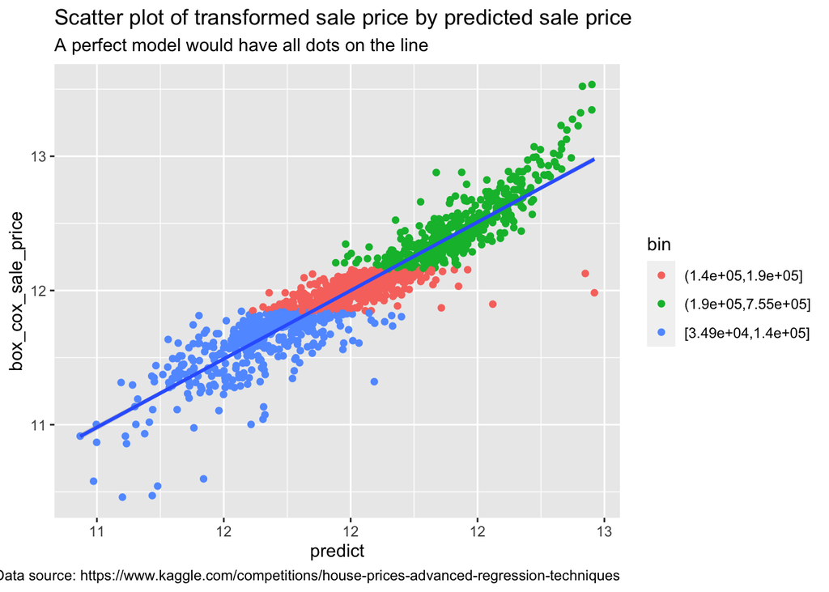

```r
library(ggplot2)
ggplot(M) +
  aes(x = predict,y = box_cox_sale_price) +
  geom_point(mapping = aes(color = bin)) +
  geom_smooth(method = "lm") +
  labs(
    title = "Scatter plot of transformed sale price by predicted sale price",
    subtitle = "A perfect model would have all dots on the line",
    caption = "Data source: https://www.kaggle.com/competitions/house-prices-advanced-regression-techniques"
  )
```

If we had a perfect model then every data point would sit on that line. So the closer the better. We also categorize the data points into 3 population of whatever value it is, so that we can see where data is more clumped together or spreaded out. Here it looks like the middle population are slightly clumped together compared to the lower and higher population.

### B. Vigintile/Decile Plot

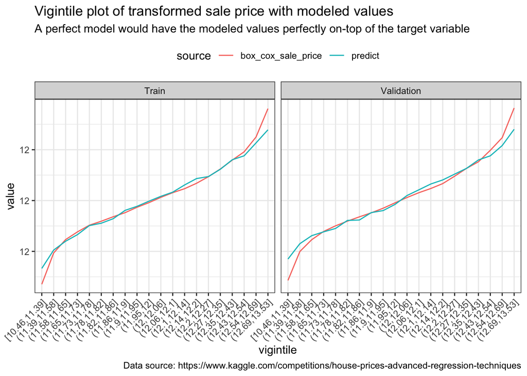

```r
M_plot <- M %>%
  dplyr::mutate(
    vigintile = cut_number(box_cox_sale_price,n = 20)
  ) %>%
  dplyr::group_by(vigintile,train_test) %>% # Ignore warning, its not an error
  dplyr::summarise(
    box_cox_sale_price = mean(box_cox_sale_price),
    predict = mean(predict)
  ) %>%
  tidyr::gather(key = "source",value = "value",box_cox_sale_price,predict) %>%
  dplyr::ungroup() %>%
  as.data.frame()
  ggplot(M_plot) +
    aes(x = vigintile,y = value,color = source,group = source) +
    geom_line() +
    facet_grid(~train_test) +
    theme_bw() +
    theme(axis.text.x = element_text(angle = 45, vjust = 1, hjust=1),legend.position = "top") +
  labs(
    title = "Vigintile plot of transformed sale price with modeled values",
    subtitle = "A perfect model would have the modeled values perfectly on-top of the target variable",
    caption = "Data source: https://www.kaggle.com/competitions/house-prices-advanced-regression-techniques"
  )
```

### C. Boxplots of Target and Predicted Values by Vigintile/Decile Bucket

Boxplots can be used to observe the distribution of the actual and predicted values within each vigintile/decile bucket. Good to check if the medians/central tendencies match up. Also good for identifying which region of the data has more variability. A perfect model would show the boxes of the predicted mirroring the actual target so the closer the better.

- Usually not good for showing stakeholders.

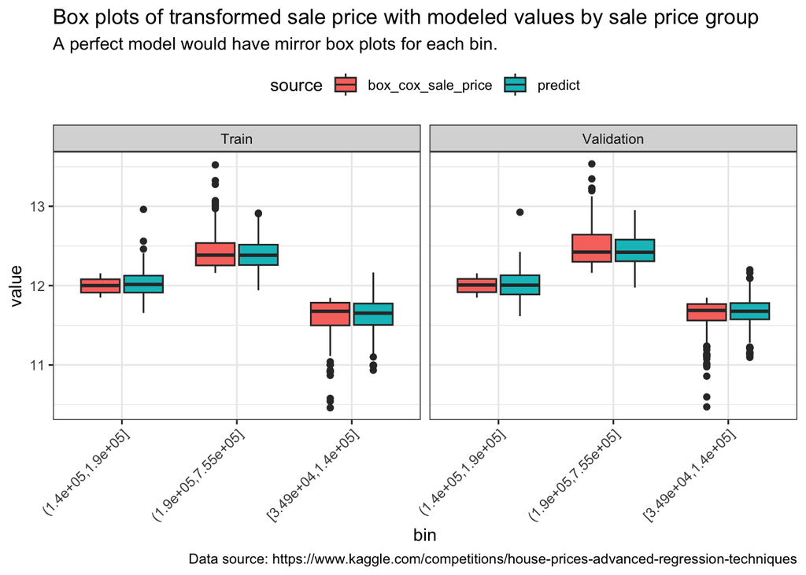

```r
M_plot <- M %>%
  dplyr::mutate(
    vigintile = cut_number(box_cox_sale_price,n = 20)
  ) %>%
  dplyr::select(box_cox_sale_price,predict,bin,train_test,vigintile) %>%
  tidyr::gather(key = "source",value = "value",box_cox_sale_price,predict)


ggplot(M_plot) +
  aes(x = bin,fill = source,y = value) +
  geom_boxplot() +
    facet_grid(~train_test) +
    theme_bw() +
    theme(axis.text.x = element_text(angle = 45, vjust = 1, hjust=1),legend.position = "top") +
  labs(
    title = "Box plots of transformed sale price with modeled values by sale price group",
    subtitle = "A perfect model would have mirror box plots for each bin.",
    caption = "Data source: https://www.kaggle.com/competitions/house-prices-advanced-regression-techniques"
  )
```

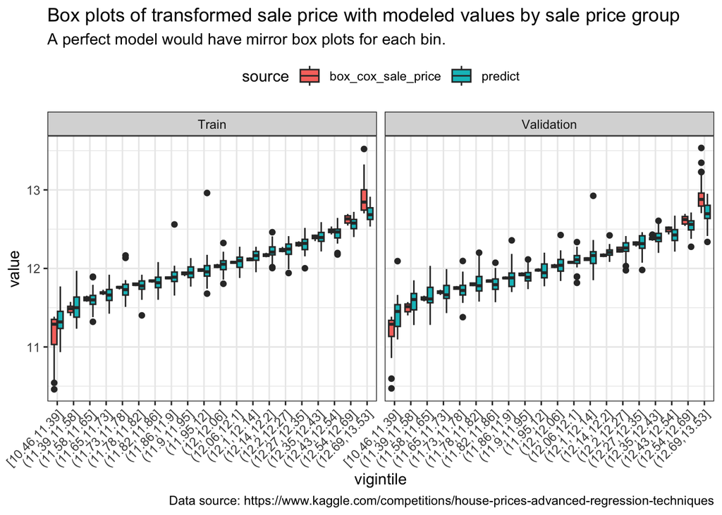

```r
ggplot(M_plot) +
  aes(x = vigintile,fill = source,y = value) +
  geom_boxplot() +
    facet_grid(~train_test) +
    theme_bw() +
    theme(axis.text.x = element_text(angle = 45, vjust = 1, hjust=1),legend.position = "top") +
  labs(
    title = "Box plots of transformed sale price with modeled values by sale price group",
    subtitle = "A perfect model would have mirror box plots for each bin.",
    caption = "Data source: https://www.kaggle.com/competitions/house-prices-advanced-regression-techniques"
  )
```

## Conclusion

Model evaluation metrics and visualizations are essential tools for understanding the quality and performance of supervised learning models. The metrics provide a quantitative evaluation, while the visualizations offer a deeper, more intuitive insight into the model’s predictions. When combined, they allow for a comprehensive assessment that can guide further model refinements.

## Homework Assignment

1. **Model Creation**: Using your prepared data from a previous homework assignment, fit a linear regression model.
2. **Metrics Evaluation**: Calculate the following metrics for your model:
   - Mean Squared Error (MSE)
   - Root Mean Squared Error (RMSE)
   - Mean Absolute Error (MAE)
   - Correlation between Target Variable and Predicted Values
   - Akaike’s Information Criterion (AIC)
   - Bayesian Information Criterion (BIC)
3. **Visualizations**:
   - Create a scatterplot of the target variable by predicted values.
   - Create a vigintile or decile plot of the target variable by predicted values.
   - Produce boxplots of target and predicted values by vigintile or decile bucket.
4. **Analysis**: Based on your metrics and visualizations, provide a short summary of your model’s performance. Identify areas where the model performs well and where it might need improvement.